# Movie Recommender

## Loading the Movielens Dataset

```r
if(!require(tidyverse)) install.packages("tidyverse", repos = "http://cran.us.r-project.org")
if(!require(caret)) install.packages("caret", repos = "http://cran.us.r-project.org")
if(!require(data.table)) install.packages("data.table", repos = "http://cran.us.r-project.org")
```

```r
dl <- tempfile()
download.file("http://files.grouplens.org/datasets/movielens/ml-10m.zip", dl)
```

```r
ratings <- fread(text = gsub("::", "\t", readLines(unzip(dl, "ml-10M100K/ratings.dat"))),
                 col.names = c("userId", "movieId", "rating", "timestamp"))

movies <- str_split_fixed(readLines(unzip(dl, "ml-10M100K/movies.dat")), "\\::", 3)
colnames(movies) <- c("movieId", "title", "genres")

movies <- as.data.frame(movies) %>% mutate(movieId = as.numeric(levels(movieId))[movieId],
                                           title = as.character(title),
                                           genres = as.character(genres))

movielens <- left_join(ratings, movies, by = "movieId")
```

```r
# Validation set will be 10% of MovieLens data

set.seed(1)
test_index <- createDataPartition(y = movielens$rating, times = 1, p = 0.1, list = FALSE)
edx <- movielens[-test_index,]
temp <- movielens[test_index,]

validation <- temp %>%
     semi_join(edx, by = "movieId") %>%
     semi_join(edx, by = "userId")

# Add rows removed from validation set back into edx set
removed <- anti_join(temp, validation)
edx <- rbind(edx, removed)

rm(dl, ratings, movies, test_index, temp, movielens, removed)
```

## Deriving Insights from the Data

```r
edx %>% as_tibble()
```

| userId | movieId | rating | timestamp | title | genres |
| --- | --- | --- | --- | --- | --- |
| 1 | 122 | 5 | 838985046 | Boomerang (1992) | Comedy\|Romance |
| 1 | 185 | 5 | 838983525 | Net, The (1995) | Action\|Crime\|Thriller |
| 1 | 231 | 5 | 838983392 | Dumb & Dumber (1994) | Comedy |
| 1 | 292 | 5 | 838983421 | Outbreak (1995) | Action\|Drama\|Sci-Fi\|Thriller |
| 1 | 316 | 5 | 838983392 | Stargate (1994) | Action\|Adventure\|Sci-Fi |
| 1 | 329 | 5 | 838983392 | Star Trek: Generations (1994) | Action\|Adventure\|Drama\|Sci-Fi |
| 1 | 355 | 5 | 838984474 | Flintstones, The (1994) | Children\|Comedy\|Fantasy |
| 1 | 356 | 5 | 838983653 | Forrest Gump (1994) | Comedy\|Drama\|Romance\|War |
| 1 | 362 | 5 | 838984885 | Jungle Book, The (1994) | Adventure\|Children\|Romance |
| 1 | 364 | 5 | 838983707 | Lion King, The (1994) | Adventure\|Animation\|Children\|Drama\|Musical |
| 1 | 370 | 5 | 838984596 | Naked Gun 33 1/3: The Final Insult (1994) | Action\|Comedy |
| 1 | 377 | 5 | 838983834 | Speed (1994) | Action\|Romance\|Thriller |
| 1 | 420 | 5 | 838983834 | Beverly Hills Cop III (1994) | Action\|Comedy\|Crime\|Thriller |
| 1 | 466 | 5 | 838984679 | Hot Shots! Part Deux (1993) | Action\|Comedy\|War |
| 1 | 480 | 5 | 838983653 | Jurassic Park (1993) | Action\|Adventure\|Sci-Fi\|Thriller |
| 1 | 520 | 5 | 838984679 | Robin Hood: Men in Tights (1993) | Comedy |
| 1 | 539 | 5 | 838984068 | Sleepless in Seattle (1993) | Comedy\|Drama\|Romance |
| 1 | 586 | 5 | 838984068 | Home Alone (1990) | Children\|Comedy |
| 1 | 589 | 5 | 838983778 | Terminator 2: Judgment Day (1991) | Action\|Sci-Fi |
| 1 | 594 | 5 | 838984679 | Snow White and the Seven Dwarfs (1937) | Animation\|Children\|Drama\|Fantasy\|Musical |
| 1 | 616 | 5 | 838984941 | Aristocats, The (1970) | Animation\|Children |
| 2 | 110 | 5 | 868245777 | Braveheart (1995) | Action\|Drama\|War |
| 2 | 151 | 3 | 868246450 | Rob Roy (1995) | Action\|Drama\|Romance\|War |
| 2 | 260 | 5 | 868244562 | Star Wars: Episode IV - A New Hope (a.k.a. Star Wars) (1977) | Action\|Adventure\|Sci-Fi |
| 2 | 376 | 3 | 868245920 | River Wild, The (1994) | Action\|Thriller |
| 2 | 539 | 3 | 868246262 | Sleepless in Seattle (1993) | Comedy\|Drama\|Romance |
| 2 | 590 | 5 | 868245608 | Dances with Wolves (1990) | Adventure\|Drama\|Western |
| 2 | 648 | 2 | 868244699 | Mission: Impossible (1996) | Action\|Adventure\|Mystery\|Thriller |
| 2 | 719 | 3 | 868246191 | Multiplicity (1996) | Comedy |
| 2 | 733 | 3 | 868244562 | Rock, The (1996) | Action\|Adventure\|Thriller |
| ... | ... | ... | ... | ... | ... |
| 71567 | 1805 | 4.0 | 912649010 | Wild Things (1998) | Crime\|Drama\|Mystery\|Thriller |
| 71567 | 1833 | 3.0 | 912649171 | Mercury Rising (1998) | Action\|Drama\|Thriller |
| 71567 | 1876 | 3.0 | 912580722 | Deep Impact (1998) | Drama\|Sci-Fi\|Thriller |
| 71567 | 1909 | 2.0 | 912580688 | X-Files: Fight the Future, The (1998) | Action\|Crime\|Mystery\|Sci-Fi\|Thriller |
| 71567 | 1917 | 4.0 | 912580787 | Armageddon (1998) | Action\|Romance\|Sci-Fi\|Thriller |
| 71567 | 1920 | 4.0 | 912578247 | Small Soldiers (1998) | Animation\|Children\|Fantasy\|War |
| 71567 | 1984 | 1.0 | 912580553 | Halloween III: Season of the Witch (1982) | Horror |
| 71567 | 1985 | 1.0 | 912580553 | Halloween 4: The Return of Michael Myers (1988) | Horror |
| 71567 | 1986 | 1.0 | 912580553 | Halloween 5: The Revenge of Michael Myers (1989) | Horror |
| 71567 | 2012 | 3.0 | 912580722 | Back to the Future Part III (1990) | Comedy\|Sci-Fi\|Western |
| 71567 | 2028 | 5.0 | 912580344 | Saving Private Ryan (1998) | Action\|Drama\|War |
| 71567 | 2107 | 1.0 | 912580553 | Halloween H20: 20 Years Later (1998) | Horror\|Thriller |
| 71567 | 2126 | 2.0 | 912649143 | Snake Eyes (1998) | Action\|Crime\|Mystery\|Thriller |
| 71567 | 2294 | 5.0 | 912577968 | Antz (1998) | Adventure\|Animation\|Children\|Comedy\|Fantasy |
| 71567 | 2338 | 2.0 | 912578016 | I Still Know What You Did Last Summer (1998) | Horror\|Mystery\|Thriller |
| 71567 | 2384 | 2.0 | 912578173 | Babe: Pig in the City (1998) | Children\|Comedy |
| 22802 | 62237 | 3.5 | 1223980874 | Part of the Weekend Never Dies (2008) | Documentary |
| 22842 | 62063 | 3.0 | 1224915851 | Dead Man's Letters (Pisma myortvogo cheloveka) (1986) | Drama\|Film-Noir |
| 23140 | 39439 | 3.5 | 1159527126 | God's Sandbox (Tahara) (2002) | Drama |
| 27946 | 61950 | 4.0 | 1222693334 | Boot Camp (2007) | Thriller |
| 27946 | 63327 | 3.0 | 1226730298 | Säg att du älskar mig (2006) | Drama |
| 30445 | 8394 | 0.5 | 1200074027 | Hi-Line, The (1999) | Drama |
| 40976 | 61913 | 3.0 | 1227767528 | Africa addio (1966) | Documentary |
| 50035 | 7568 | 3.5 | 1206386494 | Love Life (2001) | Comedy\|Romance |
| 56915 | 62245 | 4.0 | 1223985447 | Music Room, The (Jalsaghar) (1958) | Drama |
| 59269 | 59680 | 3.0 | 1229014701 | One Hour with You (1932) | Comedy\|Musical\|Romance |
| 59269 | 64325 | 3.0 | 1229014646 | Long Night, The (1947) | Crime\|Drama\|Film-Noir\|Romance\|Thriller |
| 59342 | 61768 | 0.5 | 1230070861 | Accused (Anklaget) (2005) | Drama |
| 60713 | 4820 | 2.0 | 1119156754 | Won't Anybody Listen? (2000) | Documentary |
| 68986 | 61950 | 3.5 | 1223376391 | Boot Camp (2007) | Thriller |

Now we are finding out the distinct number of users, total number of movies in our dataset and the minimum and maximum rating given by the users

```r
edx %>% summarize(
n_users=n_distinct(userId),# unique users from train
n_movies=n_distinct(movieId),# unique movies from train
min_rating=min(rating),  # the lowest rating
max_rating=max(rating) # the highest rating
)
```

| n_users | n_movies | min_rating | max_rating |
| --- | --- | --- | --- |
| 69878 | 10677 | 0.5 | 5 |

Now to check if there are any NA values in the dataset, we are going to check for 5 userID's

```r
keep <- edx %>%
  count(movieId) %>%
  top_n(5, n) %>%
  .$movieId

tab <- edx %>%
filter(movieId%in%keep) %>%
filter(userId %in% c(13:20)) %>%
select(userId, title, rating) %>%
mutate(title = str_remove(title, ", The"),title = str_remove(title, ":.*")) %>% spread(title, rating)
tab %>% knitr::kable()
```

```
| userId| Forrest Gump (1994)| Jurassic Park (1993)| Pulp Fiction (1994)| Shawshank Redemption (1994)| Silence of the Lambs (1991)|
|------:|-------------------:|--------------------:|-------------------:|---------------------------:|---------------------------:|
|     13|                  NA|                   NA|                   4|                          NA|                          NA|
|     16|                  NA|                    3|                  NA|                          NA|                          NA|
|     17|                  NA|                   NA|                  NA|                          NA|                           5|
|     18|                 4.5|                   NA|                   5|                         4.5|                          NA|
|     19|                 4.0|                    1|                  NA|                         4.0|                          NA|
```

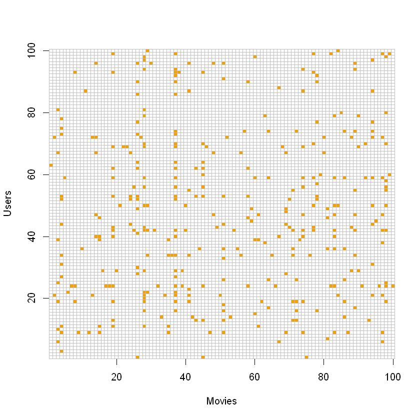

```r
users <- sample(unique(edx$userId), 100)
#rafalib::mypar()
edx%>% filter(userId %in% users) %>%
select(userId, movieId, rating) %>%
mutate(rating = 1) %>%
spread(movieId, rating) %>% select(sample(ncol(.), 100)) %>%
as.matrix() %>% t(.) %>%
image(1:100, 1:100,. , xlab="Movies", ylab="Users")
abline(h=0:100+0.5, v=0:100+0.5, col = "grey")
```

Here we notice is that some movies get rated more than others. Here is the distribution:

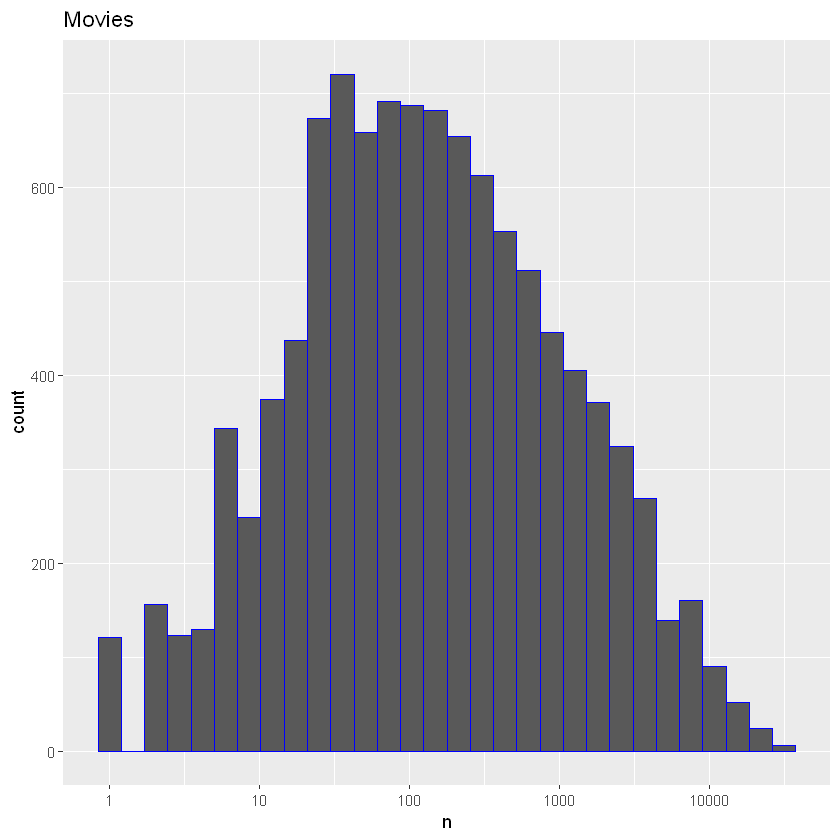

```r
# plot count rating by movie
edx %>%
count(movieId) %>%
ggplot(aes(n)) +
geom_histogram(bins = 30, color = "blue") +
scale_x_log10() +
ggtitle("Movies")
```

Also, some users are more active than others at rating movies:

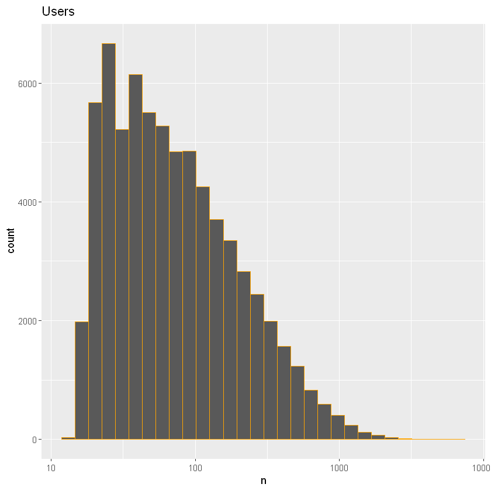

```r
edx %>%
count(userId) %>%
ggplot(aes(n)) +
geom_histogram(bins = 30, color = "orange") +
scale_x_log10() +
ggtitle("Users")
```

```r
rm(tab, keep, users)
```

## Method 1: Predicting the same rating for all movies regardless of user

```r
mu <- mean(edx$rating) # mean rating
mu
```

3.51246397107753

```r
RMSE <- function(true_ratings, predicted_ratings){
    sqrt(mean((true_ratings - predicted_ratings)^2))
}
```

```r
naive_rmse <- RMSE(edx$rating, mu) # root mean square error
naive_rmse
```

1.06039261570451

Now, as we will be using various methods to try to get the RMSE value as low as possible as we have decided on this parameter to assess our model, We are creating a Results Table.

```r
rmse_results <- tibble(method = "Normal average", RMSE = naive_rmse)
rmse_results %>% knitr::kable()
```

```
|method         |     RMSE|
|:--------------|--------:|
|Normal average | 1.060393|
```

## Movie Effects on test set

From the visualizations earlier, we can show that different movies are rated differently. Thus b_i is the bias with a movie having the ranking 'i'

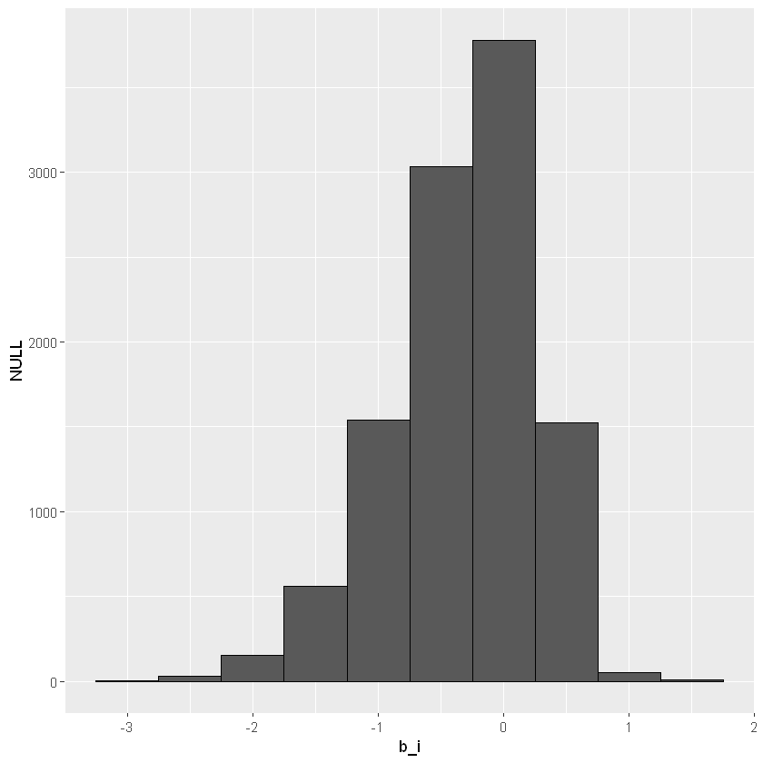

```r
mu <- mean(edx$rating)
movie_avgs <- edx %>%
  group_by(movieId) %>%
  summarize(b_i = mean(rating - mu))
movie_avgs %>% qplot(b_i, geom ="histogram", bins = 10, data = ., color = I("black"))
```

```r
predicted_ratings <- mu + edx %>%
  left_join(movie_avgs, by='movieId') %>%
  .$b_i

# create a results table with this and prior approach
model_1_rmse <- RMSE(predicted_ratings, edx$rating)
rmse_results <- bind_rows(rmse_results,
                          tibble(method="Movie Effect Model on test set",
                                     RMSE = model_1_rmse ))
rmse_results %>% knitr::kable()
```

```
|method                         |     RMSE|
|:------------------------------|--------:|
|Normal average                 | 1.060393|
|Movie Effect Model on test set | 0.942368|
```

## Movie and User Effects Model on test set

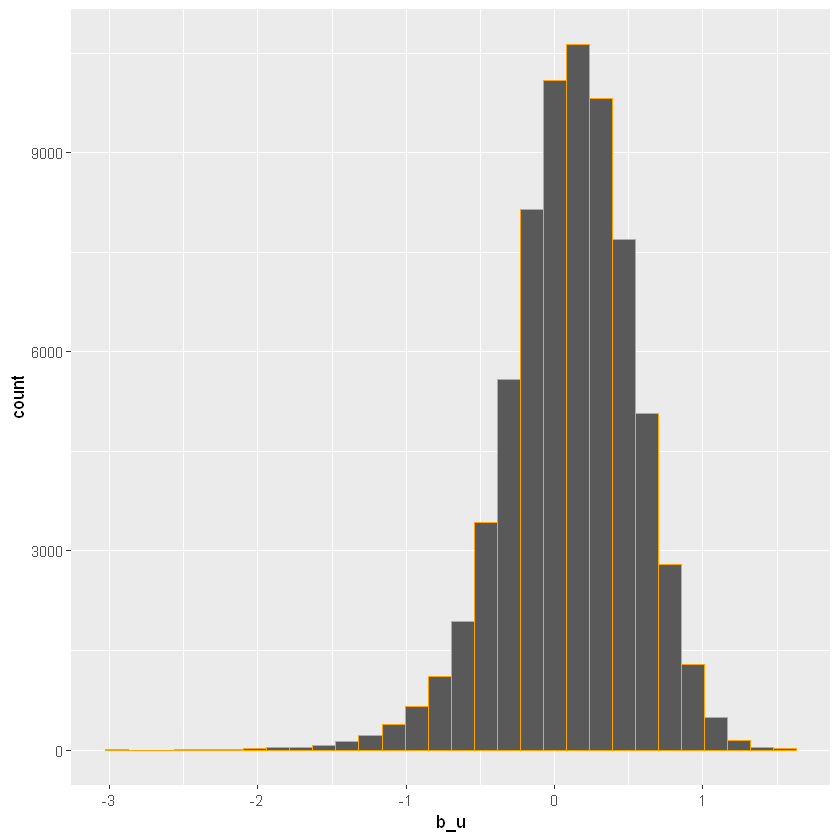

```r
edx %>%
  group_by(userId) %>%
  summarize(b_u = mean(rating - mu)) %>%
  ggplot(aes(b_u)) +
  geom_histogram(bins = 30, color = "orange")
```

```r
user_avgs <- edx %>%
  left_join(movie_avgs, by='movieId') %>%
  group_by(userId) %>%
  summarize(b_u = mean(rating - mu - b_i))
```

```r
predicted_ratings <- edx %>%
  left_join(movie_avgs, by='movieId') %>%
  left_join(user_avgs, by='userId') %>%
  mutate(pred = mu + b_i + b_u) %>%
  .$pred

# create a results table with this and prior approaches
model_2_rmse <- RMSE(predicted_ratings, edx$rating)
rmse_results <- bind_rows(rmse_results,
                          tibble(method="Movie and User Effects Model on test set",
                                     RMSE = model_2_rmse ))
rmse_results %>% knitr::kable()
```

```
|method                                   |      RMSE|
|:----------------------------------------|---------:|
|Normal average                           | 1.0603926|
|Movie Effect Model on test set           | 0.9423680|
|Movie and User Effects Model on test set | 0.8566699|
```

## Regularization

Regularization permits us to penalize large estimates that are formed using small sample sizes.These are noisy estimates that we should not trust, especially when it comes to prediction. Large errors can increase our RMSE, so we would rather be conservative when unsure.

```r
movie_titles <- edx %>%
  select(movieId, title) %>%
  distinct()
```

The Following are the top 10 best movies according to our estimate:

```r
movie_avgs %>% left_join(movie_titles, by="movieId") %>%
  arrange(desc(b_i)) %>%
  select(title, b_i) %>%
  slice(1:10) %>%
  knitr::kable()
```

```
|title                                                                            |      b_i|
|:--------------------------------------------------------------------------------|--------:|
|Hellhounds on My Trail (1999)                                                    | 1.487536|
|Satan's Tango (SÃ¡tÃ¡ntangÃ³) (1994)                                             | 1.487536|
|Shadows of Forgotten Ancestors (1964)                                            | 1.487536|
|Fighting Elegy (Kenka erejii) (1966)                                             | 1.487536|
|Sun Alley (Sonnenallee) (1999)                                                   | 1.487536|
|Blue Light, The (Das Blaue Licht) (1932)                                         | 1.487536|
|Constantine's Sword (2007)                                                       | 1.487536|
|Human Condition II, The (Ningen no joken II) (1959)                              | 1.320869|
|Who's Singin' Over There? (a.k.a. Who Sings Over There) (Ko to tamo peva) (1980) | 1.237536|
|Human Condition III, The (Ningen no joken III) (1961)                            | 1.237536|
```

And these are the 10 worst movies we get:

```r
movie_avgs %>% left_join(movie_titles, by="movieId") %>%
  arrange(b_i) %>%
  select(title, b_i) %>%
  slice(1:10) %>%
  knitr::kable()
```

```
|title                                     |       b_i|
|:-----------------------------------------|---------:|
|Besotted (2001)                           | -3.012464|
|Hi-Line, The (1999)                       | -3.012464|
|Grief (1993)                              | -3.012464|
|Accused (Anklaget) (2005)                 | -3.012464|
|War of the Worlds 2: The Next Wave (2008) | -2.762464|
|SuperBabies: Baby Geniuses 2 (2004)       | -2.698905|
|Hip Hop Witch, Da (2000)                  | -2.679131|
|From Justin to Kelly (2003)               | -2.583171|
|Disaster Movie (2008)                     | -2.528593|
|Stacy's Knights (1982)                    | -2.512464|
```

Now we will check the count of the 10 best movies, i.e. how many times were they rated

```r
edx %>% count(movieId) %>%
  left_join(movie_avgs) %>%
  left_join(movie_titles, by="movieId") %>%
  arrange(desc(b_i)) %>%
  select(title, b_i, n) %>%
  slice(1:10) %>%
  knitr::kable()
```

```
|title                                                                            |      b_i|  n|
|:--------------------------------------------------------------------------------|--------:|--:|
|Hellhounds on My Trail (1999)                                                    | 1.487536|  1|
|Satan's Tango (SÃ¡tÃ¡ntangÃ³) (1994)                                             | 1.487536|  2|
|Shadows of Forgotten Ancestors (1964)                                            | 1.487536|  1|
|Fighting Elegy (Kenka erejii) (1966)                                             | 1.487536|  1|
|Sun Alley (Sonnenallee) (1999)                                                   | 1.487536|  1|
|Blue Light, The (Das Blaue Licht) (1932)                                         | 1.487536|  1|
|Constantine's Sword (2007)                                                       | 1.487536|  1|
|Human Condition II, The (Ningen no joken II) (1959)                              | 1.320869|  3|
|Who's Singin' Over There? (a.k.a. Who Sings Over There) (Ko to tamo peva) (1980) | 1.237536|  4|
|Human Condition III, The (Ningen no joken III) (1961)                            | 1.237536|  4|
```

```r
edx %>% count(movieId) %>%
  left_join(movie_avgs) %>%
  left_join(movie_titles, by="movieId") %>%
  arrange(b_i) %>%
  select(title, b_i, n) %>%
  slice(1:10) %>%
  knitr::kable()
```

```
|title                                     |       b_i|   n|
|:-----------------------------------------|---------:|---:|
|Besotted (2001)                           | -3.012464|   2|
|Hi-Line, The (1999)                       | -3.012464|   1|
|Grief (1993)                              | -3.012464|   1|
|Accused (Anklaget) (2005)                 | -3.012464|   1|
|War of the Worlds 2: The Next Wave (2008) | -2.762464|   2|
|SuperBabies: Baby Geniuses 2 (2004)       | -2.698905|  59|
|Hip Hop Witch, Da (2000)                  | -2.679131|  12|
|From Justin to Kelly (2003)               | -2.583171| 198|
|Disaster Movie (2008)                     | -2.528593|  31|
|Stacy's Knights (1982)                    | -2.512464|   1|
```

Here we use cross-validation

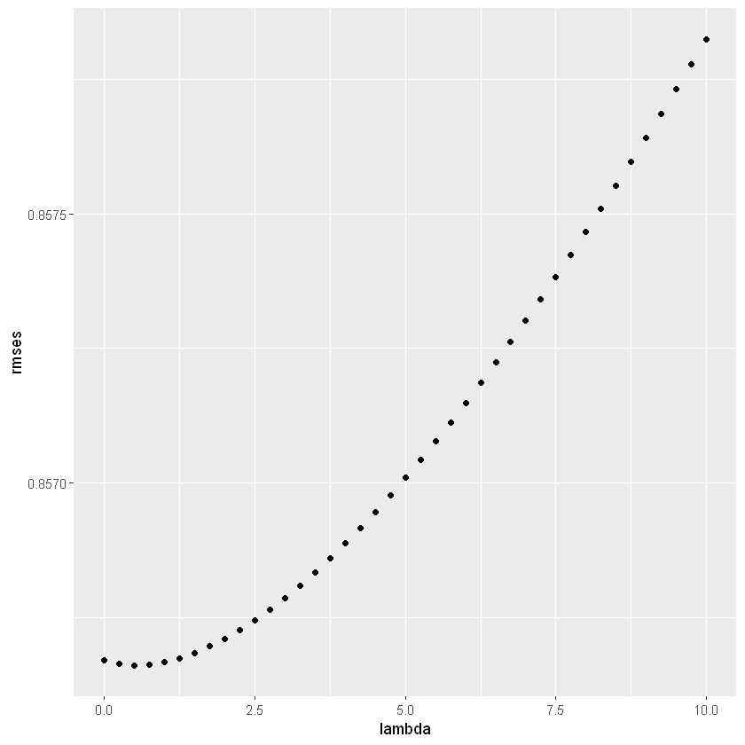

```r
lambda <- seq(0, 10, 0.25)

rmses <- sapply(lambda, function(l){
  mu <- mean(edx$rating)

  b_i <- edx %>%
    group_by(movieId) %>%
    summarize(b_i = sum(rating - mu)/(n()+l))

  b_u <- edx %>%
    left_join(b_i, by="movieId") %>%
    group_by(userId) %>%
    summarize(b_u = sum(rating - b_i - mu)/(n()+l))

  predicted_ratings <-
    edx %>%
    left_join(b_i, by = "movieId") %>%
    left_join(b_u, by = "userId") %>%
    mutate(pred = mu + b_i + b_u) %>%
    .$pred

  return(RMSE(edx$rating, predicted_ratings))
})

qplot(lambda, rmses)
```

```r
# lamda having minmal RMSE
lambda <- lambda[which.min(rmses)]
lambda
```

0.5

```r
b_i <- edx %>%
  group_by(movieId) %>%
  summarize(b_i = sum(rating - mu)/(n()+lambda))

# compute user effect with regularization on train set
b_u <- edx %>%
    left_join(b_i, by="movieId") %>%
    group_by(userId) %>%
    summarize(b_u = sum(rating - b_i - mu)/(n()+lambda))

# # compute predicted values on test set
predicted_ratings <-
    edx %>%
    left_join(b_i, by = "movieId") %>%
    left_join(b_u, by = "userId") %>%
    mutate(pred = mu + b_i + b_u) %>%
    pull(pred)

# create a results table with this and prior approaches
model_3_rmse <- RMSE(edx$rating, predicted_ratings)

rmse_results <- bind_rows(rmse_results,
                          tibble(method="Reg Movie and User Effect Model on test set",
                                 RMSE = model_3_rmse))
rmse_results %>% knitr::kable()
```

```
|method                                      |      RMSE|
|:-------------------------------------------|---------:|
|Normal average                              | 1.0603926|
|Movie Effect Model on test set              | 0.9423680|
|Movie and User Effects Model on test set    | 0.8566699|
|Reg Movie and User Effect Model on test set | 0.8566611|
```

```r
# compute movie effect without regularization on train set
b_i <- edx %>%
  group_by(movieId) %>%
  summarize(b_i = mean(rating - mu))

# compute user effect without regularization on train set
b_u <- edx %>%
    left_join(b_i, by="movieId") %>%
    group_by(userId) %>%
    summarize(b_u = mean(rating - b_i - mu))

# compute residuals on train set
train <- edx %>%
  left_join(b_i, by = "movieId") %>%
  left_join(b_u, by = "userId") %>%
  mutate(res = rating - mu - b_i - b_u)

# compute residuals on test set
test <- edx %>%
  left_join(b_i, by = "movieId") %>%
  left_join(b_u, by = "userId") %>%
  mutate(res = rating - mu - b_i - b_u)
```

The long dataset prevents obscure movies with just a few users increase our RMSE, so the regularization does not produce significant improvements in performance using the RMSE as a metric. Thus, we focus on the movies and users effects to calculate the residuals. These residuals are modeled using Matrix Factorization

```r
if(!require(recosystem)) install.packages("recosystem", repos = "http://cran.r-project.org")
```

```r
train_data <- data_memory(user_index = train$userId, item_index = train$movieId,
                          rating = train$res, index1 = T)

test_data <- data_memory(user_index = test$userId, item_index = test$movieId, index1 = T)

# create a model object
recommender <- Reco()
```

The following code trains a recommender model. It will read from a training data source and create a model file at the specified location. The model file contains necessary information for prediction.

```r
set.seed(1)
suppressWarnings(recommender$train(train_data, opts = c(dim = 30, costp_l1 = 0,
                                                        costp_l2 = 0.01, costq_l1 = 0,
                                                        costq_l2 = 0.1, lrate = 0.05,
                                                        verbose = FALSE)))
```

```r
predicted_ratings <- recommender$predict(test_data, out_memory()) + mu + test$b_i + test$b_u
```

```r
ind <- which(predicted_ratings > 5)
predicted_ratings[ind] <- 5

# floor rating at 0.50
ind <- which(predicted_ratings < 0.5)
predicted_ratings[ind] <- 0.5

# create a results table with this approach
model_4_rmse <- RMSE(test$rating, predicted_ratings)

rmse_results <- bind_rows(rmse_results,
                          tibble(method="Movie and User + Matrix Fact. on test set",
                                   RMSE = model_4_rmse))
rmse_results %>% knitr::kable()
```

```
|method                                      |      RMSE|
|:-------------------------------------------|---------:|
|Normal average                              | 1.0603926|
|Movie Effect Model on test set              | 0.9423680|
|Movie and User Effects Model on test set    | 0.8566699|
|Reg Movie and User Effect Model on test set | 0.8566611|
|Movie and User + Matrix Fact. on test set   | 0.7425414|
```

```r
# compute movies effect without regularization on edx set
b_i <- edx %>%
  group_by(movieId) %>%
  summarize(b_i = mean(rating - mu))

# compute users effect without regularization on edx set
b_u <- edx %>%
    left_join(b_i, by="movieId") %>%
    group_by(userId) %>%
    summarize(b_u = mean(rating - b_i - mu))

# compute residuals on edx set
edx <- edx %>%
  left_join(b_i, by = "movieId") %>%
  left_join(b_u, by = "userId") %>%
  mutate(res = rating - mu - b_i - b_u)

# compute residuals on validation set
validation <- validation %>%
  left_join(b_i, by = "movieId") %>%
  left_join(b_u, by = "userId") %>%
  mutate(res = rating - mu - b_i - b_u)

# Using recosystem
# create data saved on disk in 3 columns with no headers

edx_data <- data_memory(user_index = edx$userId, item_index = edx$movieId,
                          rating = edx$res, index1 = T)

validation_data <- data_memory(user_index = validation$userId, item_index = validation$movieId, index1 = T)

# create a model object
recommender <- Reco()

# Train the model by calling the `$train()` method
# some parameters coming from the result of `$tune()`
# This is a randomized algorithm
set.seed(1)

suppressWarnings(recommender$train(edx_data, opts = c(dim = 30, costp_l1 = 0,
                                                        costp_l2 = 0.01, costq_l1 = 0,
                                                        costq_l2 = 0.1, lrate = 0.05,
                                                        verbose = FALSE)))

# use the `$predict()` method to compute predicted values
# return predicted values in memory

predicted_ratings <- recommender$predict(validation_data, out_memory()) + mu +
                       validation$b_i + validation$b_u

# ceiling rating at 5
ind <- which(predicted_ratings > 5)
predicted_ratings[ind] <- 5

# floor rating at 5
ind <- which(predicted_ratings < 0.5)
predicted_ratings[ind] <- 0.5

# create a results table with this and prior approaches
model_5_rmse <- RMSE(validation$rating, predicted_ratings)

rmse_results <- bind_rows(rmse_results,
                          tibble(method="Movie and User effects and Matrix Fact. on validation set",
                                   RMSE = model_5_rmse))
rmse_results %>% knitr::kable()
```

```
|method                                                    |      RMSE|
|:---------------------------------------------------------|---------:|
|Normal average                                            | 1.0603926|
|Movie Effect Model on test set                            | 0.9423680|
|Movie and User Effects Model on test set                  | 0.8566699|
|Reg Movie and User Effect Model on test set               | 0.8566611|
|Movie and User + Matrix Fact. on test set                 | 0.7425414|
|Movie and User effects and Matrix Fact. on validation set | 0.7948597|
```